# A1_2_Regresion_lineal

## **A1.2 Regresión lineal**

Dede 2012 el World Happiness Report (WHR) ha propuesto una metodología para estimar un concepto tan complejo y dificil de medir, la felicidad. De manera que, a partir de estos estudios, factores económicos, sociales y de salud han sido analizados con posibles explicaciones basandose en las diferencias presentes entre países. Entre ellos, el producto interno bruto (GDP) y otros elementos relevantes.

Asimismo, se hará uso de la base de datos bajo el nombre **“A1.2 Felicidad y GDP.csv”**, presentándose información sobre el nivel de felicidad reportado en 2022 y el GDP correspondiente a 2020 para distintos países. De esta forma, se llevará a cabo un análisis de la relación entre la felicidad y variables económicas y sociales mediante modelos de regresión lineal, explorando tanto un enfoque de regresión lineal simple como uno de regresión lineal múltiple.

Cabe destacar que, al trabajar con variables económicas, se considerarán transformaciones adecuadas para así trabajar con variables lineales. Analizando así, la conveniencia de utilizar o no una transformación.

**Exploración y contextualización de los datos**

Expertos en economía, psicología, sociología y otras disciplinas analizan información interdisciplinaria sobre el bienestar y la felicidad de las personas el mundo. Para ello, el Centro de Investigación del Bienestar de la Universidad de Oxford, en colaboración con Gallup, la SDSN y un consejo editorial independiente clasifica anualmente a 146 países la evaluación del promedio de la calidad de vida de la población. Pidiendo a los encuestados calificar su vida actual en una escala del 0 al 10, donde 10 representa la mejor vida posible y 0 la peor. [1]

Si bien, estos resultados se basan en autopercepción, se consideran como factor clave el producto interno bruto (GDP), es decir, el conjunto de bienes y servicios producidos por un país durante un año. [2]

El conjunto de datos disponible cuenta con tres variables principales:

- `País` variable categórica que indica el país representante.
- `Felicidad` variable cuantitativa que indica la percepción de felicidad en una escala de 0-10.
- `GDP` variable cuantitativa que indica el producto interno bruto de cada país con dolares como unidad.

Para dar inicio con el análisis técnico es necesario cargar los datos pertenecientes a **“A1.2 Felicidad y GDP.csv”**.

Para ello, una vez que el archivo se encuentre en la carpeta en uso; es esencial importar al ambiente de trabajo una librería de análisis de datos, utilizando la declaración `import` para acceder a las funciones de `pandas` mediante la abreviatura `pd`.

De manera que, por medio de una variable de nombre `data` se hará uso de la función `read_csv()` de pandas, la cual nos permitirá realizar la lectura de datos.

```python
import pandas as pd
data =pd.read_csv('A1.2 Felicidad y GDP.csv')
```

Igualmente, es necesario revisar el contenido del presente archivo. Mediante la función `print()` se aplicará la función `head()` en la variable `data`, desplegando por default las primeras cinco filas de datos.

```python
print(data.head())
```

```
          Pais  Felicidad           GDP
0      Finland     7.8210  2.718370e+11
1      Denmark     7.6362  3.560850e+11
2      Iceland     7.5575  2.171808e+10
3  Switzerland     7.5116  7.522480e+11
4  Netherlands     7.4149  9.138650e+11
```

De igual manera, para conocer más a detalle la población analizada se utilizará la función describe(). Permitiéndonos resaltar estadísticamente los datos, brindándonos variables numéricas que nos permitirán tener mayor comprensión de la información que analizamos.

```python
data.describe()
```

|  | Felicidad | GDP |
| --- | --- | --- |
| count | 141.000000 | 1.410000e+02 |
| mean | 5.560004 | 5.889942e+11 |
| std | 1.098011 | 2.221612e+12 |
| min | 2.403800 | 1.223876e+09 |
| 25% | 4.887900 | 1.805117e+10 |
| 50% | 5.585300 | 6.215800e+10 |
| 75% | 6.309100 | 3.452960e+11 |
| max | 7.821000 | 2.089370e+13 |

Demostrando que el nivel de felicidad promedio entre los 141 países analizados es de 5.56. Además de contar con una desviación estandar de 2.22 × 10¹², lo cual muestra una variación grande entre las diversas economías.

Por su parte, para el análisis gráfico de la relación entre la variable de salida `Felicidad` y la variable cuantitativa `GDP`, se mostrará su comportamiento en los diferentes países.

Donde, con un gráfico de dispersión utilizando la función `plt.scatter()` por medio del módulo `pyplot`que cuenta con las funciones necesarias para crear gráficos. Se establecerá en el eje horizontal el logaritmo natural del GDP `np.log(GDP)` y, en el eje vertical los niveles de felicidad.

Cabe destacar que, tras el análisis previamente realizado se determinó el uso del logaritmo; esto debido a que el GDP muestra valores en escalas diferentes, lo cual complicaría el análisis de patrones. Dicha transformación logarítmica comprimirá la escala y facilitará la identificación de tendencias.

Finalmente, continuaremos el análisis con la función `corr()` aplicada sobre las variables analizadas, lo cual nos permitirá calcular la correlación numérica entre las variables.

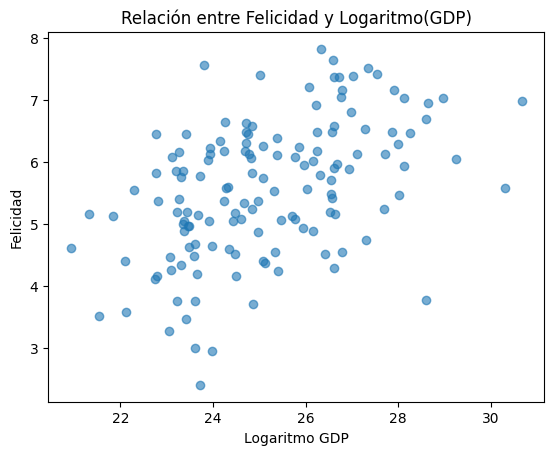

```
           Felicidad    LogGDP
Felicidad   1.000000  0.470812
LogGDP      0.470812  1.000000
```

```python
import numpy as np
import matplotlib.pyplot as plt

plt.scatter(np.log(data["GDP"]), data["Felicidad"], alpha=0.6)
plt.xlabel("Logaritmo GDP")
plt.ylabel("Felicidad")
plt.title("Relación entre Felicidad y Logaritmo(GDP)")
plt.show()

data["LogGDP"] = np.log(data["GDP"])
print(data[["Felicidad","LogGDP"]].corr())
```

Así, es más sencillo observar a detalle la contextualización de países en relación a sus niveles de felicidad y economías:

- Países con felicidad alta y economía moderada: Países tales como Finlandia, Dinamarca, Islandia, Suecia y Noruega muestran los niveles de felicidad más altos, contando con economías moderadas y sólidas que conllevan una distribución equitativa de recursos, brindando una calidad de vida que parece compensar el resto.
- Países felicidad moderada y economía alta: Países tales como Estados Unidos, China, Alemania, China y Japón cuentan con economías muy altas, sin embargo, sus niveles de felicidad no se encuentran entre los más altos. Sugiriendo que el GDP por si mismo no garantiza el bienestar y que factores externos pueden influir.
- Países felicidad moderada y economía moderada: Países tales como Uruguay, Costa Rica, México y Guatemala cuentan con niveles de felicidad alta en comparación de su economía, sin llegar a ser Los países con GDP más alto. Reflejando que otros factores poueden influir en la percepción de bienestar de la población.
- Países felicidad baja y economía baja: Países tales como Afganistan y Zimbawue presentan tanto felicidad como economía baja, lo cual puede estar relacionado con la inestabilidad política o acceso limitado a recursos. [3]

Donde, por medio de la correlación realizada es posible observar un valor de 0.470 entre las variables analizadas, demostrando una relación medianamente positiva (al ser un valor moderadamente cercano a uno). Indicando que hay una tendencia, donde a mayor GDP (en escala logarítmica), mayor nivel de felicidad.

Permitiendonos comprender que aunque el GDP tiene cierta relación con la felicidad, sería esencial considerar otros factores (sociales, culturales o políticos) que pueden tener un impacto directo con el bienestar de la población.

**Modelo de regresión lineal simple**

Para analizar un poco más a detalle el uso de un indicador económico como lo es el **GDP**, se utilizará como variable explicativa del nivel de felicidad. Donde, a pesar de haber identificado previamente una correlación medianamente positiva, es pertinente profundizar al análisis para evaluar más a detalle la fuerza de la asociación. Utilizando el logaritmo del GDP para observar relaciones más lineales.

De esta forma, se planteo un modelo de regresión lineal simple que permitirá estimar el efecto del GDP sobre la felicidad y su significancia estadística de la asociación, a través de la siguiente ecuación:

Felicidad_i= B_0 + B_1 * logaritmo GDP

Utilizando la función antes descrita `np.log()` para la trasformación del GDP y `LinealRegression` para ajustar un modelo lineal simple que relaciona `Logaritmo GDP` con `Felicidad`. Donde, con el uso de `fit()` se estiman los coeficiantes para así visualizarlo en un gráfico mediante `plt.plot` y `plt.scatter`.

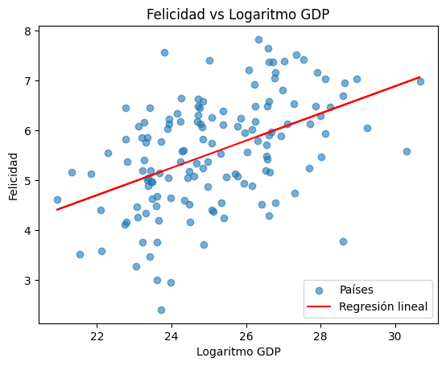

```python
import numpy as np
import matplotlib.pyplot as plt
from sklearn.linear_model import LinearRegression

data["LogGDP"] = np.log(data["GDP"])
X = data[["LogGDP"]]
y = data["Felicidad"]

#Modelo lineal
modelo = LinearRegression().fit(X, y)

# Gráfico
plt.scatter(X, y, alpha=0.6, label="Países")
plt.plot(X, modelo.predict(X), color="red", label="Regresión lineal")
plt.xlabel("Logaritmo GDP")
plt.ylabel("Felicidad")
plt.title("Felicidad vs Logaritmo GDP")
plt.legend()
plt.show()
```

De esta forma, al usar la función `OLS` perteneciente a statsmodels es posibe ajustar el modelo de regresión lineal simple entre las variables. Imprimiendo el `p-value` y `R²`, para así analizar si la asociación es significativa que tanto explica la felicidad.

```python
import statsmodels.api as sm

print("Intercección B_0:", modelo.intercept_)
print("Pendiente B_1:", modelo.coef_[0])

modelo = sm.OLS(y, X).fit()
print("p-value:", modelo.pvalues["LogGDP"])
print("R²:", modelo.rsquared)
```

```
Intercección B_0: -1.3023500570747295
Pendiente B_1: 0.2727927266584911
p-value: 3.3709774380325026e-109
R²: 0.9706878979910954
```

Comprendiendo que el GDP mantiene una relación importante con la felicidad en la mayoría de los casos; no obstante, reconociendo que existen otros factores que Influyen directamente en el bienestar de la población.

**Extensión del conjunto de datos**

Para extender el análisis en un escenario más realista, se desarrollará un modelo de regresión lineal múltiple utilizando el nivel de felicidad distintos países como variable dependiente.

Asimismo, se integrarán tres variables adicionales obtenidas del *World Happines Report* perteneciente al año 2022. [4]

Las variables seleccionadas fueron:

- *Esperanza de vida saludable (Healthy life expectancy)*: Indicador de la expectativa de vida saludable, relacionándose a las condiciones de salud que la población percibe en una escala de 0-1.
- *Libertad de tomar desiciones de vida (Freedom to make life choices)*: Indicador de la percepción de libertad para tomar decisiones personales, siendo un factor social que impacta en la satisfacción y bienestar de las personas, en una escala 0-1.
- *Percepción de corrupción (Perceptions of corruption)*: Indicador de la confianza en instituciones y como estas se relacionan con la corrupción, afectando así la confianza social de la comunidad, en una escala de 0-1.

Cabe reiterar que, mientras que el nivel de felicidad se mide en una escala de 0-10, las variables adicionales *Esperanza de vida saludable, Libertad de tomar desiciones y Percepción de la corrupción* se expresan como índices normalizados entre 0-1, lo que permite realizar comparaciones internacionales dentro de la misma escala. [5]

De manera que, es posible estudiar todos los países analizados en el archivo original, al contar con datos completos de las variables adicionales seleccionadas. Permitiendo mantener una diversidad de contextos nacionales, pero implicando una combinación de perspectivas y realidades muy distintas.

Así, podremos evaluar más a detalle los determinantes de felicidad, considerando más allá de los factores económicos, sino también factores sociales, políticos y de salud, que nos brindarán un panorama más amplio de el bienestar en distintos contextos.

Al subir el archivo nombrado **“Variables_Adicionales.csv”**, de manera similar a lo realizado con el archivo original, es posible visualizar las primeras cinco lineas de información.

```python
import pandas as pd
dato = pd.read_csv("Variables_Adicionales.csv")
print(dato.head())
```

```
       Country  Happiness score  Healthy life expectancy  \
0      Finland            7.821                    0.775
1      Denmark            7.636                    0.777
2      Iceland            7.557                    0.803
3  Switzerland            7.512                    0.822
4  Netherlands            7.415                    0.787

    Freedom to make life choices   Perceptions of corruption
0                          0.736                       0.534
1                          0.719                       0.532
2                          0.718                       0.191
3                          0.677                       0.461
4                          0.651                       0.419
```

**Modelo de regresión lineal múltiple**

El modelo de regresión lineal múltiple permitirá analizar como varias variables explican en conjunto una variable dependiente. En este caso, la variable dependiente es el *nivel de felicidad* y las variable independientes: *Healthy life expectancy, Freedom to make life choices y Perceptions of corruption*.

Usando la siguiente ecuación como modelo a seguir:

Felicidad = B_0 + B_1 * Healthy life expectancy + B_2 * Freedom to make life choices + B_3 * Perceptions of corruption

Al seleccionar las variables independientes y dependiente, se añadió una constante para ajustar el modelo de regresión lineal múltiple con `OLS`. Mostrando con la Función `modelo.summary()` los coeficientes, su significancia y el `R²` del modelo. [6]

```python
dato.columns = dato.columns.str.strip()
X = dato[["Healthy life expectancy","Freedom to make life choices","Perceptions of corruption"]]
y = dato["Happiness score"]

X = sm.add_constant(X)
modelo = sm.OLS(y, X).fit()

#Resumen estadístico
print(modelo.summary())
```

```
                            OLS Regression Results
==============================================================================
Dep. Variable:        Happiness score   R-squared:                       0.672
Model:                            OLS   Adj. R-squared:                  0.664
Method:                 Least Squares   F-statistic:                     93.39
Date:                Sun, 25 Jan 2026   Prob (F-statistic):           5.78e-33
Time:                        19:37:17   Log-Likelihood:                -134.17
No. Observations:                 141   AIC:                             276.3
Df Residuals:                     137   BIC:                             288.1
Df Model:                           3
Covariance Type:            nonrobust
================================================================================================
                                   coef    std err          t      P>|t|      [0.025      0.975]
------------------------------------------------------------------------------------------------
const                            1.9851      0.231      8.583      0.000       1.528       2.442
Healthy life expectancy          3.5780      0.349     10.238      0.000       2.887       4.269
Freedom to make life choices     2.6795      0.430      6.226      0.000       1.829       3.531
Perceptions of corruption        0.5380      0.470      1.146      0.254      -0.391       1.467
==============================================================================
Omnibus:                       19.356   Durbin-Watson:                   1.493
Prob(Omnibus):                  0.000   Jarque-Bera (JB):               22.767
Skew:                          -0.890   Prob(JB):                     1.14e-05
Kurtosis:                       3.840   Cond. No.                         12.7
==============================================================================

Notes:
[1] Standard Errors assume that the covariance matrix of the errors is correctly specified.
```

A partir de las tres variables: esperanza de vida saludable, libertad para tomar decisiones y percepción de corrupción; el resumen estadístico busca explicar el nivel de la felicidad. Mostrando así que el modelo cuenta con un buen ajuste, al contar con `R² = 0.672`, indicando que las variables analizadas explican aproximadamente 67% de variabilidad de felicidad.

Donde, los coeficientes de *Healthy life expectancy* (3.578) y *Freedom to make life choices* (2.679) son positivos y significativos (p < 0.001), mostrando que cuentan con influencia en el bienestar de la población. Mientras que, el coeficiente de la variable *Perceptions of corruption* (0.538) no es estadísticamente significativo (p = 0.254 > 0.05), indicando que esta variable tiene un efecto más debil sobre la felicidad y poco explicativo en el modelo.

Dejando claro que, las variables esperanza de vida saludable y la libertad para tomar decisiones son factores más determinantes en la explicación de la felicidad; mientras que la percepción de corrupción tiene un efecto menor y estadísticamente no significativo. Indicando que el bienestar en los países depende principalmente de las condiciones de libertad social y salud de calidad, dejando a los factores institucionales con una baja influencia.

**Comparación de modelos y conclusiones**

Para realizar la comparacióN entre los modelos de regresión, se analizará tanto el modelo simple (basado en el logaritmo de GDP), como el modelo múltiple, que toma en cuenta variables adicionales relacionadas a la salud, percepción de la corrupción, y libertad.

Teniendo como objetivo evaluar si al incluir factores sociales y de calidad de vida, se observa de manera significativa la capacidad explicativa del modelo relacionado a la felicidad. Empleando métricas tales como el RSS (Residual Sum of Squares) Y RSE (Residual Standard Error), qu permiten cuantificar la precisión de las predicciones y establecer una postura crítica respecto a ventajas y limitaciones de cada enfoque.

```python
# RSS
rss_simple = np.sum((y - m1.predict())**2)
rss_multi  = np.sum((y - m2.predict())**2)

# RSE
rse_simple = np.sqrt(rss_simple / (len(y) - 2))
rse_multi  = np.sqrt(rss_multi / (len(y) - 4))

print("RSS simple:", rss_simple, "RSE simple:", rse_simple)
print("RSS múltiple:", rss_multi, "RSE múltiple:", rse_multi)
```

```
RSS simple: 131.31769225337453 RSE simple: 0.9719730443510974
RSS múltiple: 55.36976874249635 RSE múltiple: 0.6357349258383012
```

Tras lo antes observado, podemos determinar que la capacidad explicativa mejora al tomar en cuenta variables adicionales. El modelo simple, basado unicamente en el logaritmo de GDP, cuenta con un `RSS = 131.32` y un `RSE = 0.97`, reflejando una considerable disperción en los errores de predicción. Mientras que el modelo múltiple, que incluye variables relacionadas a la salud y bienestar social, reducen los valores a un `RSS = 55.37` Y `RSE = 0.64`.

Por su parte, tras realizar un analisis detallado de la influencia de diversos factores en la percepción de la felicidad de distintos países es posible concluir lo siguiente:

- La incorporación de variables adicionales mejora de manera significativa la capacidad explicativa del modelo.
- A pesar de tener hallazgos que muestran una precisión estadística, se presentan limitaciones al no ser posible capturar las perspectivas subjetivas sobre la felicidad.
- Para lograr una comprensión más amplia de la felicidad, podrían condiderarse indicadores más complejos e incluso subjetivos. Que permitirán ampliar el análisis más allá del factor económico y así encontrar elementos decisivos en la explicación de la felicidad.

### **Referencias**

1. “World Happiness Report - Sustainable Development Solutions Network.” Www.unsdsn.org, 8 May 2024, www.unsdsn.org/our-work/world-happiness-report/.
2. Rojas, Gabriela. “PIB O Felicidad.” El Economista, 21 Apr. 2016, www.eleconomista.com.mx/opinion/PIB-o-felicidad-20160420-0116.html. Accessed 25 Jan. 2026.
3. staff, B. E. R. “Beyond GDP: Economics and Happiness.” Berkeley Economic Review, 31 Oct. 2018, econreview.studentorg.berkeley.edu/beyond-gdp-economics-and-happiness/.
4. “Data Sharing.” Worldhappiness.report, 2025, www.worldhappiness.report/data-sharing/.
5. “World Happiness, Trust and Social Connections in Times of Crisis.” Worldhappiness.report, 2023, www.worldhappiness.report/ed/2023/world-happiness-trust-and-social-connections-in-times-of-crisis/.
6. “How to Get Regression Model Summary from ScikitLearn.” GeeksforGeeks, 25 June 2022, www.geeksforgeeks.org/python/how-to-get-regression-model-summary-from-scikit-learn/. Accessed 25 Jan. 2026.